# DS202A: Data Science for Social Scientists

#### **DBSCAN**

DBSCAN (Density-Based Spatial Clustering of Applications with Noise) is a machine learning algorithm that groups data points based on their density (Zhang, Ni, and Xu 2020). Unlike hierarchical clustering, DBSCAN does not require one to specify the number of clusters, k, in advance. Instead, it uses two key parameters: eps (the maximum distance between two points to be considered neighbors) and minPts (the minimum number of points required to form a cluster). The algorithm identifies regions of high density as clusters and labels points in low-density regions as noise or outliers. However, the choice of parameters is critical, as they directly influence the resulting clusters. This is a problem we ran into in our attempt to cluster using DBSCAN, and our method of dealing with this issue is detailed below.

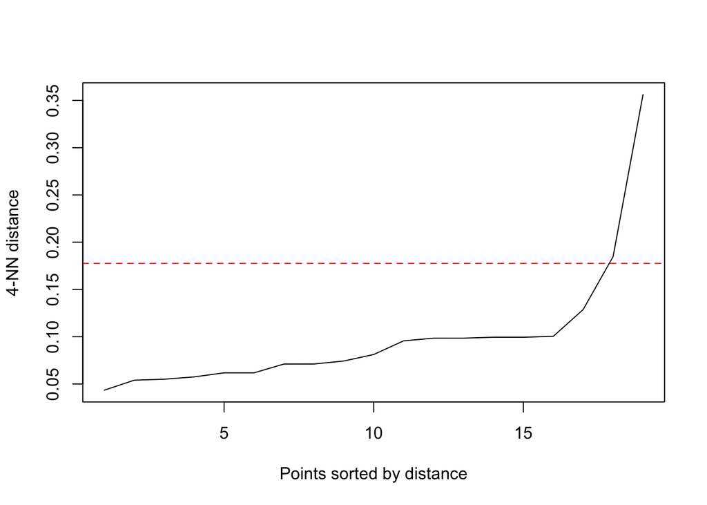

```r
js_matrix_numeric <- js_matrix[,-1]  # remove the first column (question labels)
diag(js_matrix_numeric) <- 0  # replace diagonal NAs with 0 (pairwise comparison shows no difference)

# finding the point of maximum curvature (to get eps value)
js_matrix_num <- as.matrix(js_matrix_numeric)
distances <- sort(js_matrix_num)  # sort distances
slope <- diff(distances)  # first derivative (slope) - difference between consecutive distances
curvature <- diff(slope)  # second derivative (curvature) - difference between consecutive slopes
max_curvature_index <- which.max(abs(curvature))  # find the index of maximum curvature
max_curvature_value <- distances[max_curvature_index + 1]  # value at that point (because of diff)

dbscan::kNNdistplot(js_matrix_numeric, k = 4) +
  abline(h = max_curvature_value, lty = 2, col = "red") +
  scale_y_continuous(n.breaks = 40)  # Adjust y-axis ticks
```

We found the point of maximum curvature to be 0.1775979, however found difficulty when running DBSCAN using this value as it returns one cluster, likely due to the `eps` value being large.

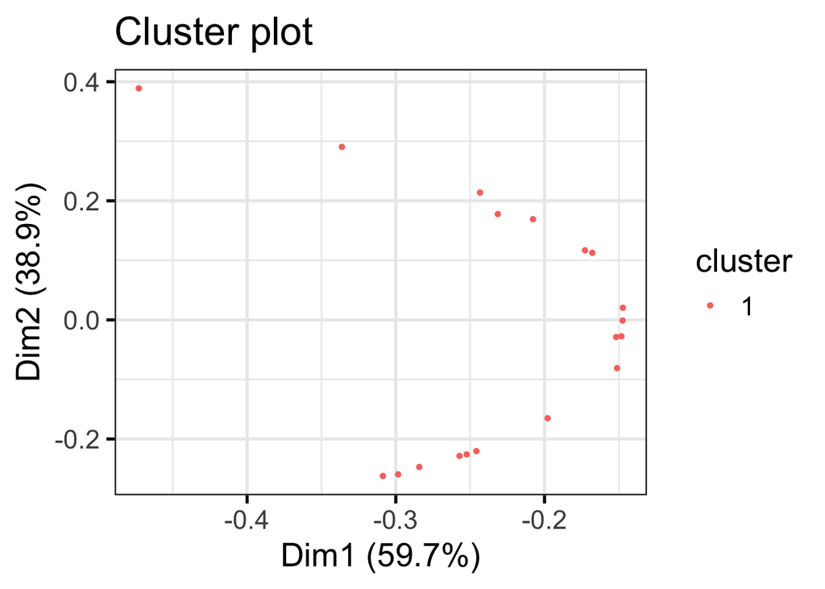

```r
db <- dbscan::dbscan(js_matrix_numeric, eps = 0.1775979, minPts = 3)
fviz_cluster(db, data = js_matrix_numeric, stand = FALSE,
             ellipse = FALSE, show.clust.cent = FALSE,
             geom = "point", ggtheme = theme_bw(base_size=20))
```

**Finding the Optimal `eps` Value**

As the maximum point of curvature is typically taken as the `eps` value, but this resulted in one cluster, we used trial and error assigning `eps` based on the 90th percentile of the curvature values.

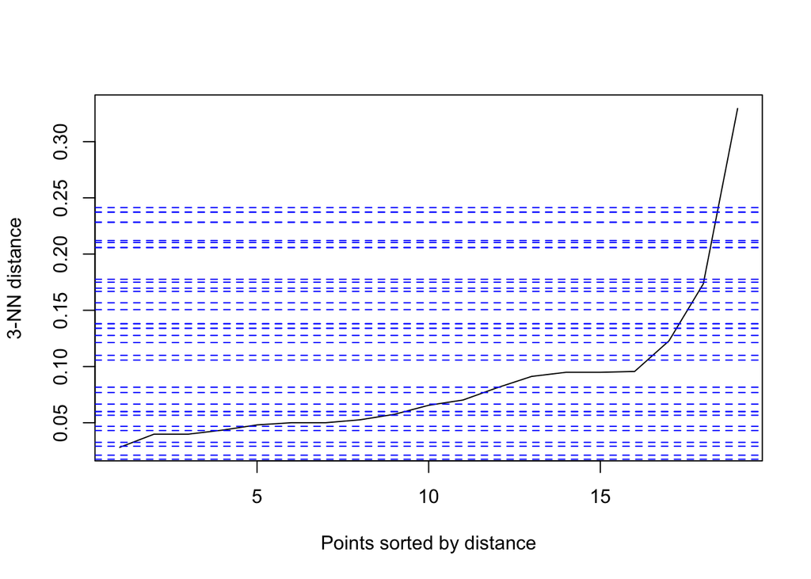

```r
# threshold based on the 90th percentile of the curvature values
threshold <- quantile(abs(curvature), 0.90)

# identify the indices of curvature values above the threshold
sharp_increase_indices <- which(abs(curvature) > threshold)

# identify the corresponding distances for these points (index + 1 due to diff)
sharp_increase_values <- distances[sharp_increase_indices + 1]

# plot the kNN distances
library(ggplot2)
p <- dbscan::kNNdistplot(js_matrix_numeric, k = 3) +
  scale_y_continuous(n.breaks = 40)

# add the first abline for the maximum curvature (already identified)
p <- p + abline(h = max_curvature_value, lty = 2, col = "red")

# add additional ablines for other sharp increases
for (i in 1:length(sharp_increase_values)) {
  p <- p + abline(h = sharp_increase_values[i], lty = 2, col = "blue")
}
```

**Determining an `eps`** **Value** Using minPts = 4 (as it is twice the number of dimensions), and eps = 0.08, we gain three clusters, and two “noise” points. The outcome of which aligns with our intuitive grouping, and with hierarchical clustering.

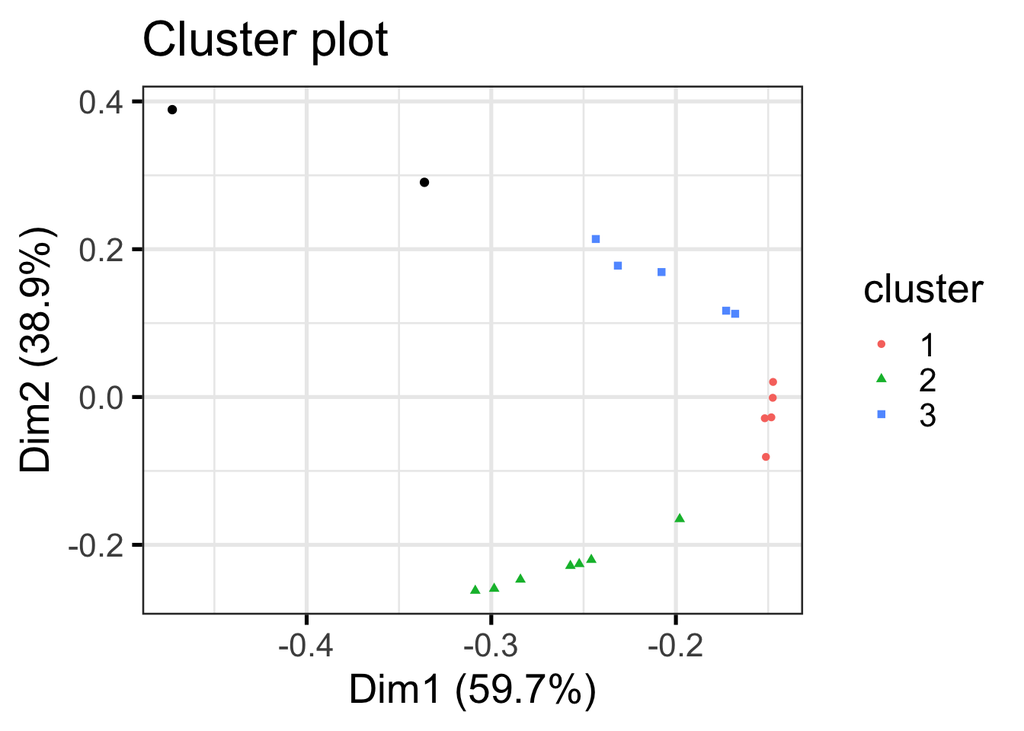

```r
# Create a vector of the question labels (Q177 to Q195)
question_labels <- c("Claiming Benefits", "Avoiding Transport Fare", "Stealing Property",
                     "Tax Cheating", "Accepting Bribe", "Homosexuality", "Prostitution",
                     "Abortion", "Divorce", "Sex Before Marriage", "Suicide", "Euthanasia",
                     "Wife Beating", "Child Beating", "Violence Against Others", "Terrorism",
                     "Casual Sex", "Political Violence", "Death Penalty")

# Run DBSCAN
db <- dbscan::dbscan(js_matrix_numeric, eps = 0.08, minPts = 4)

# Plot DBSCAN results
library(factoextra)
fviz_cluster(db, data = js_matrix_numeric, stand = FALSE,
             ellipse = FALSE, show.clust.cent = FALSE,
             geom = "point", ggtheme = theme_bw(base_size = 20))
```

**Outcome at `eps` = 0.08 and `minPts` = 4**

1. Claiming Unentitled Benefits, Avoiding Transport Fare, Prostitution, Suicide, Child Beating
2. Stealing Property, Tax Cheating, Accepting Bribe, Wife Beating, Violence Against Others, Terrorism, Political Violence
3. Homosexuality, Abortion, Euthanasia, Casual Sex, Death Penalty

Noise: Divorce, Sex Before Marriage

### Discussion of the Final Clusters

The Spearman correlation, hierarchical clustering, and DBSCAN provide valuable insights into how different actions are grouped based on their justification distributions. Using Jensen-Shannon divergence, hierarchical clustering with k = 4 revealed four distinct clusters, with Divorce standing out as an outlier, reinforcing its unique position in moral attitudes compared to other actions. However, Spearman correlation identifies Child Beating and the Death Penalty as ‘outliers’ (as they are in their own distinct cluster). Meanwhile, DBSCAN, which identifies clusters based on density rather than predefined groupings, produced three main clusters with two noise points, one of which being Divorce, aligning with our intuition and hierarchical results. The consistency between hierarchical clustering and DBSCAN suggests that the identified groupings reflect meaningful patterns in justification attitudes rather than being an outcome due to a particular clustering approach. The presence of noise points in DBSCAN highlights actions with highly variable or ambiguous justifiability, which may indicate deep societal divides or cultural variation. These findings set the stage for further analysis into regional variations and socio-cultural influences on moral attitudes.

# 2. Are There Regional Differences When It Comes to This?

This section aims to investigate regional differences in values, based on the justifiability across countries of the set of actions discussed in Section 1, in order to answer the question.

In answer to the question “Can we set universally acceptable criteria for what is right, just, good, or evil for all human behaviour and judgment?” researchers stipulate that beliefs, standards, norms, and values differ cross-culturally (Lee et al. 2004), therefore the justifiability of the aforementioned “dishonest or illegal activities” (Torgler and Valev 2010) should vary regionally, between different countries and cultures. For example, the “individualism-collectivism dimension” has been applied in explaining and predicting attitudinal and behavioural differences in which individualistic countries - like Australia, USA, and Western Europe (Green, Deschamps, and Páez 2005) - sanction the pursuit of self-interest, suggesting leniency regarding these actions, whereas “collectivist societies” adhere more to traditional social conventions, therefore would likely disapprove (Toth and Kemmelmeier 2009). However, countries and cultures differ on a multitude of dimensions, such as religiosity and religious beliefs (Roberts 2019), political liberalism and conservatism (McGee, Benk, and Yüzbaşı 2015), national wealth (Stack, Adamczyk, and Cao 2010), and family values (Lee et al. 1996) (Toth and Kemmelmeier 2009), therefore the potential regional differences in attitudes to Q177-195 are arguably more complex than simple individualism-collectivism classifications.

**Methodology**

To conduct comparative analysis at the country level requires a metric to represent the aggregate responses from within countries. As discussed previously, we recognise the limitations of these averages, especially in the presence of such highly skewed data. As such, in Section 2.1 we first work with the geometric mean of the distribution of responses for each question per country, which provides a partial remedy to the misrepresentation of the arithmetic mean. This allows for clear initial visualisation of national variation, which we plot, for two questions, onto a world map to better understand how the responses vary by geographic region.

Following this, in Section 2.2, we calculate the Jensen-Shannon Divergence (JSD) for each country-question pair, which allows for comparisons using the entire distributions of responses per country. JSD pairs are used to establish (dis)similarities between countries, then fed into a hierarchical clustering to group countries by response patterns. We fit these clusters to a world map and discuss how our observations regarding regional difference fit with the regional values literature.

Finally, we provide some preliminary explanations for potential regional differences in justifiability, by testing the significance of several predictor variables also drawn from the WVS survey.

## 2.1 Country Means

The clearest way to observe inter-national variation is comparison of national average figures. Therefore, we begin with an overview of mean national responses to the justifiability of each action.

### 2.1.1 Geometric Mean per Question, per Country

```r
geometric_means <- wvs_qs %>%
  group_by(country_name) %>%
  mutate(B_COUNTRY_ALPHA = first(B_COUNTRY_ALPHA)) %>%
  summarise(
    B_COUNTRY_ALPHA = first(B_COUNTRY_ALPHA),
    across(Q177:Q195, ~exp(mean(log(.), na.rm = TRUE)))
    )
  # Create long format df
geometric_means_long <- geometric_means %>%
  pivot_longer(cols = -c(country_name, B_COUNTRY_ALPHA),
              names_to = "Question",
              values_to = "GEOMETRIC_MEAN")
```

[interactive chart not shown]

This plot captures the mean justifiability of each action, with countries plotted along the x-axis. Responses show significant divergence between countries, particularly for certain questions, helping to identify moral consensus and divergence across countries for each action. Actions such as “Violence Against Others” show low justification scores across most countries, indicating broad societal disapproval. Conversely, actions like “Divorce” exhibit higher justification scores in some countries but remain controversial in others (e.g. Nigeria, Kyrgyzstan). Whilst the clearest patterns are the central horizontal grouping of more ‘controversial’ questions discussed in Section 1, the vertical patterns show, for instance, that Pakistan has very low scores (1 - 2) for all questions, whereas Germany has mean justifiability of up to 8 for some questions. Germany is more supportive of various actions, having experienced an increase in support for euthanasia (Tutić Grokša et al. 2025). Similarly, homosexuality has experienced a statistically significant “upswing” in its acceptance in Western countries however not in the “Muslim World” (Roberts 2019) which includes Pakistan. This national variation provides motivation for regional comparisons especially with respect to the set of high-variance questions, which appear to generate significant variation across nationalities.

Some cells display `NaN` (Not a Number) values, indicating missing data for certain countries on specific questions. These missing values could arise due to survey non-response captured by our data cleaning, or the exclusion of certain questions in some countries (Wife Beating is not asked in the UK, for instance). As mentioned, we will not impute data. To ensure meaningful comparisons we will note these values, keeping them in the data when they do not impact certain analyses, but noting this in our results.

### 2.1.2 National-Global Mean Divergence

[interactive chart not shown]

This plot utilises the same data from the previous, but highlights more starkly the relative differences between countries. Following the vertical patterns emphasises positive and negative deviations concentrated to certain countries. Again, Pakistan is has -2 or -3 deviation from global average for several questions, whilst Germany is generally positively deviated from the global average.

### 2.1.3 Mapping Means

A helpful way to explore the potential regional patterns in this national variation is to examine differences geographically. For this, we use the `maps` and `countrycode` packages to match the `B_COUNTRY_CODE` variable to internationally recognised `iso3c` codes and retrieve national latitude and longitudinal values. Using the world map from `maps` we plot the national mean scores for the justifiability of homosexuality and the death penalty; two questions with significant national variation in responses.

#### **Homosexuality**

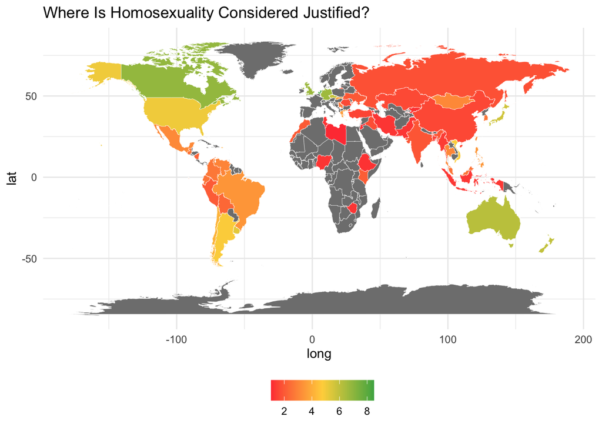

```r
# Exclude territories without values in world map data, that are not present in the WVS survey
territories_to_exclude <- c("Barbuda", "Canary Islands", "Micronesia",
                            "Heard Island", "Chagos Archipelago", "Siachen Glacier",
                            "Saint Martin",
                            "Bonaire", "Sint Eustatius","Saba", "Madeira Islands",
                            "Azores", "Ascension Island", "Grenadines",
                            "Virgin Islands", "Kosovo")


# Country codes
world_map <- map_data("world") %>%
  filter(!region %in% territories_to_exclude) %>%
  mutate(iso3c = countrycode(region,
                            origin = 'country.name',
                            destination = 'iso3c'))

# Joining justification values with the map data
map_data <- left_join(world_map, geometric_means,
                      by = c("iso3c" = "B_COUNTRY_ALPHA"))

# Map
ggplot(map_data, aes(x = long, y = lat, group = group, fill = Q182)) +
  geom_polygon(color = "white", size = 0.1) +
  #scale_fill_viridis_c() +  # or another color scale
  scale_fill_gradientn(colors = c("#ff4242", "#ffd449", "#4caf50")) +
  theme_minimal() +
  theme(legend.position = "bottom") +
  labs(fill = "",
       title = "Where Is Homosexuality Considered Justified?")
```

Homosexuality, whilst broadly justified across the Western World or Global North countries; the USA, Canada, the UK, northern Europe, Australia and New Zealand, is considered less justifiable across South American countries, very unjustifiable across Russia and Asia, and is often never justified on average in the African countries surveyed. The acceptance of homosexuality has risen across many Western countries (Roberts 2019)

#### **Death Penalty**

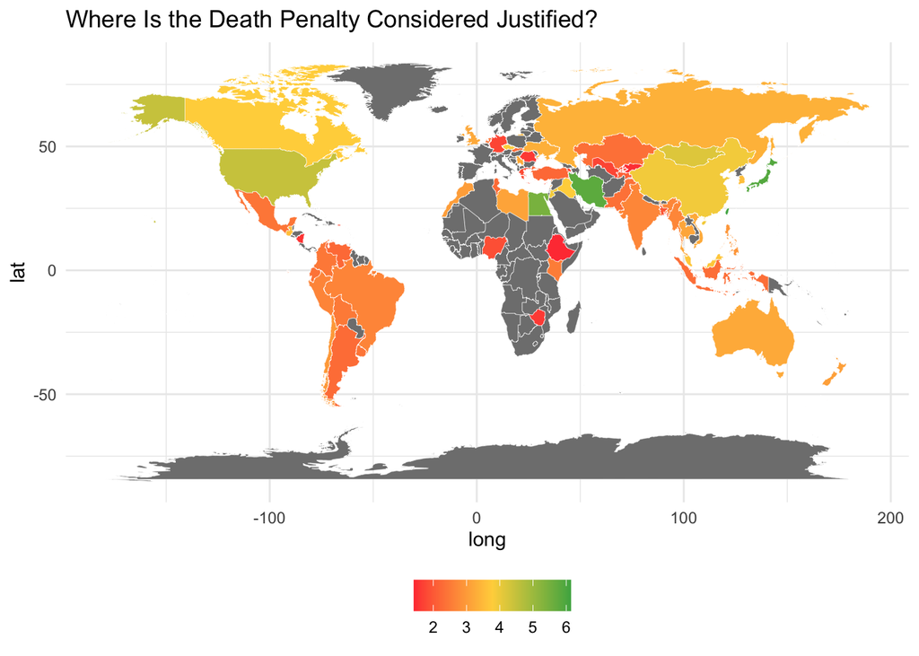

Retentionist nations (e.g., China) are more accepting and supportive of capital punishment compare to their retentionist counterparts (e.g., Germany) (McCarthy and Brunton-Smith 2024). However, the degree of support does vary within the retentionist-abolitionist groups, for example, the UK is an abolitionist nature which shows greater support for the death penalty, whereas Indonesia, a retentionist nation, is more “critical” of the practice (McCarthy and Brunton-Smith 2024).

## 2.2 National Divergence

Since grouping countries based on a single mean value hides a large amount of variation in the underlying data, and might wrongly characterise certain countries attitudes, we turn to the JS Divergence (explained in more detail in Section 1.6.2) to measure the similarity between the national distributions.

Based on our findings in Section 1, we are interested in the regional variation in responses to a set of questions, so will take the average JS divergence across these questions per country. For this analysis, we focus on a set of (broadly defined) issues of individual autonomy or ‘post-materialist values’ (Inglehart, 2009) represented within the questions, as opposed to those focussed on economic or violent actions, these are:

> Homosexuality

> Abortion

> Divorce

> Sex before marriage

> Suicide

> Euthanasia

> Casual sex

These are also the questions with the clearest national variation and least uniform distributions, which show the most meaningful variation across countries; we also expect responses to them to move broadly in the same direction, as they appear to act together (albeit not perfectly) as an indicator of progressive liberal individualism and secular attitudes.

Though it would be interesting to compare country distributions across all questions individually, we do not have the space in this paper to do so. If we included the whole set of questions then distributions moving in different directions, representing attitudes to different dimensions, would make comparisons less meaningful.

### 2.2.1 Calculate JS Divergence

**Prepare Data for Calculation**

```r
# Select questions for similarity calculation

lib_qs <-  c(
    "Q182", # = "Homosexuality"
    "Q184", # = "Abortion"
    "Q185", # = "Divorce"
    "Q186", # = "Sex Before Marriage"
    "Q187", # = "Suicide"
    "Q188", # = "Euthanasia"
    "Q193"  # = "Casual Sex"
)

#all_qs <- c("Q177","Q178","Q179","Q180","Q181","Q182","Q183","Q184","Q185","Q186",
#            "Q187","Q188","Q189","Q190","Q191","Q192","Q193","Q194","Q195")

# df for JS
wvs_select <- wvs_qs %>%
  select(country_name, B_COUNTRY_ALPHA, lib_qs)

# Long df for JS
wvs_select_long <- wvs_select %>%
  pivot_longer(
    cols = Q182:Q193,
    names_to = "question",
    values_to = "response"
    )
```

Calculate probability distributions by country and question

```r
ctry_dstr <- wvs_select_long %>%
  filter(response %in% 1:10) %>%
  group_by(country_name, B_COUNTRY_ALPHA, question, response) %>%
  summarise(count = n(), .groups = "drop") %>%
  group_by(country_name, B_COUNTRY_ALPHA, question) %>%
  mutate(probability = count / sum(count))
```

**JS Divergence**

We perform the computation using parallel processing with `detectCores` function in the `parallel` package, and `registerDoParallel` in the `doParallel` package for computational efficiency.

```r
# Parallel processing
n_cores <- detectCores() - 1  # Leave one core free
cl <- makeCluster(n_cores)
registerDoParallel(cl)

# List of countries
country_list <- unique(ctry_dstr[c("country_name", "B_COUNTRY_ALPHA")])

# Pairs of countries
country_pairs <- expand.grid(
  Country1 = country_list$country_name,
  Country2 = country_list$country_name,
  stringsAsFactors = FALSE
  ) %>%
  filter(Country1 < Country2) %>%
  # country codes
    left_join(country_list, by = c("Country1" = "country_name")) %>%
  rename(B_COUNTRY_ALPHA1 = B_COUNTRY_ALPHA) %>%
  left_join(country_list, by = c("Country2" = "country_name")) %>%
  rename(B_COUNTRY_ALPHA2 = B_COUNTRY_ALPHA)

# Computation of JS divergence
country_js_results <- foreach(i = 1:nrow(country_pairs),
                            .combine = rbind,
                            .packages = c('dplyr', 'philentropy')) %dopar% {

  Country1 <- country_pairs$Country1[i]
  Country2 <- country_pairs$Country2[i]
  B_COUNTRY_ALPHA1 <- country_pairs$B_COUNTRY_ALPHA1[i]
  B_COUNTRY_ALPHA2 <- country_pairs$B_COUNTRY_ALPHA2[i]

# Probability distributions for Country1
  prob_P <- ctry_dstr %>%
    filter(country_name == Country1)

# Probability distributions for Country2
  prob_Q <- ctry_dstr %>%
    filter(country_name == Country2)

# Average JS divergence across all questions
  question_list <- unique(prob_P$question)
  jsd_value <- mean(sapply(question_list, function(q) {
    p1 <- prob_P %>%
      filter(question == q) %>%
      arrange(response) %>%
      pull(probability)

    p2 <- prob_Q %>%
      filter(question == q) %>%
      arrange(response) %>%
      pull(probability)

    if(length(p1) > 0 && length(p2) > 0) {
      JSD(rbind(p1, p2), unit = "log2")
    } else {
      NA
    }
  }), na.rm = TRUE)

  # df results
  data.frame(
    Country1 = Country1,
    Country2 = Country2,
    B_COUNTRY_ALPHA1 = B_COUNTRY_ALPHA1,
    B_COUNTRY_ALPHA2 = B_COUNTRY_ALPHA2,
    JSD = jsd_value
  )
}

# Stop the pp cluster
stopCluster(cl)

# Results to tibble
country_js_results <- as_tibble(country_js_results)

head(country_js_results) %>% kable()
```

| Country1 | Country2 | B_COUNTRY_ALPHA1 | B_COUNTRY_ALPHA2 | JSD |
| --- | --- | --- | --- | --- |
| Andorra | Argentina | AND | ARG | 0.0836321 |
| Andorra | Armenia | AND | ARM | 0.3730577 |
| Argentina | Armenia | ARG | ARM | 0.2213274 |
| Andorra | Australia | AND | AUS | 0.0265729 |
| Argentina | Australia | ARG | AUS | 0.0859024 |
| Armenia | Australia | ARM | AUS | 0.3863945 |

### 2.2.2 Similarity

Comparing the similarity of countries’ responses to these questions provides a preliminary understanding of how countries might be grouped based on values, and how this might align with regional difference.

**Create Matrix**

Using the JS divergence values, we create an empty matrix using `matrix()` and loop each row of `country_js_results` to fill in the matrix. A previous, simpler method using `as.matrix()` led to assymetry in the matrix.

```r
# Convert to (distance) matrix for visualisation
countries_for_matrix <- sort(unique(c(country_js_results$Country1, country_js_results$Country2)))


js_matrix <- matrix(0,
                   nrow = length(countries_for_matrix),
                   ncol = length(countries_for_matrix),
                   dimnames = list(countries_for_matrix, countries_for_matrix))

for(i in 1:nrow(country_js_results)) {
  js_matrix[country_js_results$Country1[i],
            country_js_results$Country2[i]] <- country_js_results$JSD[i]
  js_matrix[country_js_results$Country2[i], country_js_results$Country1[i]] <-
    country_js_results$JSD[i]
}
```

**Most Different Countries**

```r
data.frame(
  row = row(js_matrix)[lower.tri(js_matrix)],
  col = col(js_matrix)[lower.tri(js_matrix)],
  value = js_matrix[lower.tri(js_matrix)]
) %>%
  filter(row != col) %>%  # Remove self-pairs
  arrange(desc(value)) %>%
  distinct(value, .keep_all = TRUE) %>%  # Remove duplicates
  head(5) %>%  # Get top 5
  mutate(
    Country_1 = rownames(js_matrix)[row],
    Country_2 = colnames(js_matrix)[col],
    JS_Divergence = round(value, 4)
  ) %>%
  select(Country_1, Country_2, JS_Divergence) %>%
  kable(caption = "Top 5 Most Divergent Country Pairs",
        align = c('l', 'l', 'c'))
```

Top 5 Most Divergent Country Pairs

| Country_1 | Country_2 | JS_Divergence |
| --- | --- | --- |
| South Korea | Libya | 0.7777 |
| Netherlands | Libya | 0.7507 |
| Libya | Canada | 0.7296 |
| Libya | Czechia | 0.7277 |
| Vietnam | Libya | 0.7218 |

South Korea and Libya have the greatest divergence in average distribution across the justifiability of this set of actions. But all of the 5 most divergent pairs include Libya, suggesting it has significantly unique responses compared to other countries.

**Most Similar Countries**

```r
data.frame(
  row = row(js_matrix)[lower.tri(js_matrix)],
  col = col(js_matrix)[lower.tri(js_matrix)],
  value = js_matrix[lower.tri(js_matrix)]
) %>%
  filter(row != col) %>%  # Remove self-pairs
  arrange(value) %>%      # Changed to arrange by ascending order
  distinct(value, .keep_all = TRUE) %>%  # Remove duplicates
  head(5) %>%  # Get top 5
  mutate(
    Country_1 = rownames(js_matrix)[row],
    Country_2 = colnames(js_matrix)[col],
    JS_Divergence = round(value, 4)
  ) %>%
  select(Country_1, Country_2, JS_Divergence) %>%
  kable(caption = "Top 5 Most Similar Country Pairs",  # Updated caption
        align = c('l', 'l', 'c'))
```

Top 5 Most Similar Country Pairs

| Country_1 | Country_2 | JS_Divergence |
| --- | --- | --- |
| Peru | Bolivia | 0.0058 |
| Mexico | Guatemala | 0.0077 |
| United States | Northern Ireland | 0.0081 |
| Pakistan | Indonesia | 0.0088 |
| Ecuador | Bolivia | 0.0092 |

The most similar countries are Peru and Bolivia, which are close neighbours in the same region. Similarly, Mexico and Guatemala share a border and are considered closely aligned, with similar religious makeup. Religious beliefs and religiosity are significant determinants of attitudes and values. The fact that the majority of Latin America identify as Chrisian, 69% of adults as Catholic (Wormald 2014), likely contributes to the observed similarities between these countries.

### 2.2.3 MDS Plot

Below is a multidimensional scaling plot, which provides a visualisation of the differences between countries within a 2 dimensional space, using the JS divergence measure, such that countries closer together are the more similar. The two dimensions do not have meaning in themselves, but are constructed such that the relative distances between countries are preserved, allowing us to view the space that will be analysed in the following section by the hierarchical clustering function.

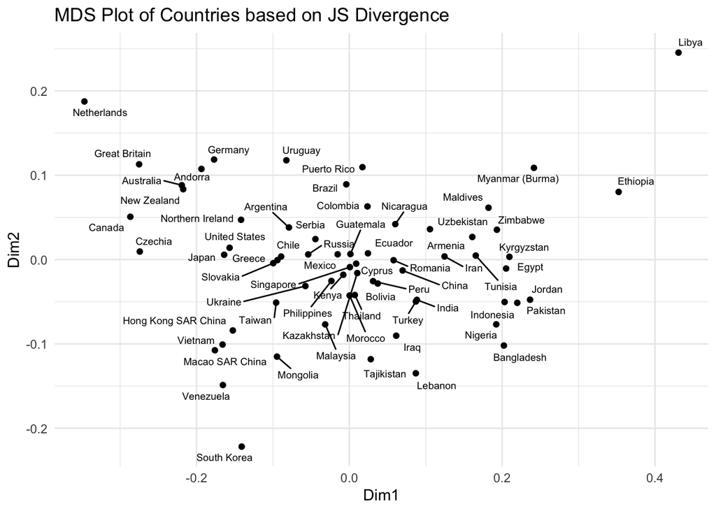

```r
#JS matrix to distance object
js_dist <- as.dist(js_matrix)

# MDS
mds_result <- cmdscale(js_dist, k=2)
mds_df <- as.data.frame(mds_result)
colnames(mds_df) <- c("Dim1", "Dim2")
mds_df$country <- rownames(js_matrix)

# Plot
ggplot(mds_df, aes(x=Dim1, y=Dim2, label=country)) +
  geom_point() +
  # text options for legibility
  geom_text_repel(
    size = 2.5,
    max.overlaps = 100,
    force = 10,
    force_pull = 0.1,
    point.padding = 0.1) +
  theme_minimal() +
  labs(title="MDS Plot of Countries based on JS Divergence")
```

We can observe several interesting patterns from this initial plot; Libya, the Netherlands, South Korea, and to a lesser extent Ethiopia and Myanmar (Burma) are outliers from the central cluster. The Netherlands may be considered an outlier as it is arguably the most progressive of the countries, described as a “culture of tolerance” in which many of the measured actions are permissible, including abortion (Loll and Hall 2019), euthanasia (Karumathil and Tripathi 2022), and, a previously discussed action, prostitution (Stack, Adamczyk, and Cao 2010). Conversely, sub-Saharan African countries, such as Ethiopia, are associated with declining rates of “positive attitudinal change” (Roberts 2019).

Western, Global North countries appear to be grouped in the upper left of the space, with Eastern European and Latin American countries closer to the centre, and a set of Middle Eastern, and Asian countries on the right. The central cluster of some Eastern European and Latin American countries may cluster due to heightened religiosity as the former “experienced a religious resurgence” post-Soviet Communism (Inglehart et al. 2021) and the majority of Latin America is religious, specifically Catholic (Wormald 2014). The Global North or Western countries are considered more culturally individualistic (Green, Deschamps, and Páez 2005) whereas, Middle Eastern and Asian countries share more collectivist traits (Karumathil and Tripathi 2022), and religion in some cases, which may explain the respective similarities of their attitudes.

## 2.3 Clustering Countries

To interrogate the similarity across countries and their possible regional divergence, we perform hierarchical clustering to group the countries. Having tried DBSCAN, we found hierarchical clusters to have more meaningful results and be more interpretable through the visualisation of the splits in a dendrogram diagram. This method also allowed us to alter the single *k* parameter easily, to compare the effect of different numbers of clusters.

### 2.3.1 Perform Hierarchical Clustering

We first use *k* = 7 clusters, following some consensus in the literature on a world split into 7 cultural regions. In an analysis of WVS data these “world regions” were specified as “the West (including Western Europe and European settler colonies in North America and the Pacific), Latin America and the Caribbean, the former Soviet and Eastern Bloc, the Muslim World, sub-Saharan Africa, South and Southeast Asia, and East Asia” (Roberts 2019).

We avoid using `"complete"` clustering, as it is sensitive to outliers, which we have already observed in our data. `"average"` produces a large number of single country clusters and groups various others together, which is not meaningful, so we use `ward.D2`, which minimises within-cluster variance and creates more balanced and evenly-sized clusters.

```r
# hierarchical clustering
hc <- hclust(as.dist(js_matrix), method = "ward.D2") # (using distance matrix)

# Number of clusters
k <- 7

# Cut tree
clusters <- cutree(hc, k)

# Data frame of cluster assignments, with B_COUNTRY_ALPHA attached
cluster_df_7 <- data.frame(
  Country = names(clusters),
  Cluster = clusters
) %>%
  distinct() %>%
   left_join(
    country_js_results %>%
      select(Country1, B_COUNTRY_ALPHA1) %>%
      distinct() %>%
      rename(Country = Country1,
             B_COUNTRY_ALPHA = B_COUNTRY_ALPHA1),
    by = "Country"
  ) %>%
  arrange(Cluster, Country)

# Print
cluster_df_7 %>%
  group_by(Cluster) %>%
  summarise(Countries = paste(Country, collapse = ", ")) %>%
  kable(col.names = c("Cluster", "Countries"),
        caption = "Countries Grouped by Cluster") %>%
  kable_styling(bootstrap_options = c("striped", "hover"),
                full_width = FALSE)
```

Countries Grouped by Cluster

| Cluster | Countries |
| --- | --- |
| 1 | Andorra, Australia, Canada, Czechia, Germany, Great Britain, Netherlands, New Zealand |
| 2 | Argentina, Chile, Greece, Hong Kong SAR China, Japan, Macao SAR China, Mongolia, Northern Ireland, Russia, Serbia, Slovakia, South Korea, Taiwan, Ukraine, United States, Uruguay, Vietnam |
| 3 | Armenia, Bangladesh, China, India, Indonesia, Iran, Iraq, Jordan, Kyrgyzstan, Lebanon, Maldives, Myanmar (Burma), Nigeria, Pakistan, Romania, Tunisia, Turkey, Uzbekistan, Zimbabwe |
| 4 | Bolivia, Brazil, Colombia, Cyprus, Ecuador, Guatemala, Kazakhstan, Kenya, Malaysia, Mexico, Morocco, Nicaragua, Peru, Philippines, Puerto Rico, Singapore, Thailand |
| 5 | Egypt, Ethiopia, Libya |
| 6 | Tajikistan |
| 7 | Venezuela |

With 7 clusters, there emerge (1) a set of European and Western countries, (2) A range of Latin American, East Asian, and Eastern European countries, along with Northern Ireland and the United States, (3) Middle Eastern, African, and South Asian countries, (4) A range of South American, African, and some East Asian countries, then (5) North African Libya and Egypt, and Ethiopia, and (6) and (7) as apparent outliers.

Whilst these groupings appear to follow some aforementioned expected cultural regional attitudes, they could be more meaningful, and we see groupings of countries with very different histories, religions and values, so we plot a dendrogram to see the structure of the clusters produced.

**Cluster Dendrogram, K = 7**

Visualising the clustering process is helpful to interpret the dissemination of each group of countries. The dendrogram using base R `plot()` shows the levels at which the clusters are split. We add boxes around clusters with `rect.hclust()`. higher values of *k* to further differentiate across the clusters.

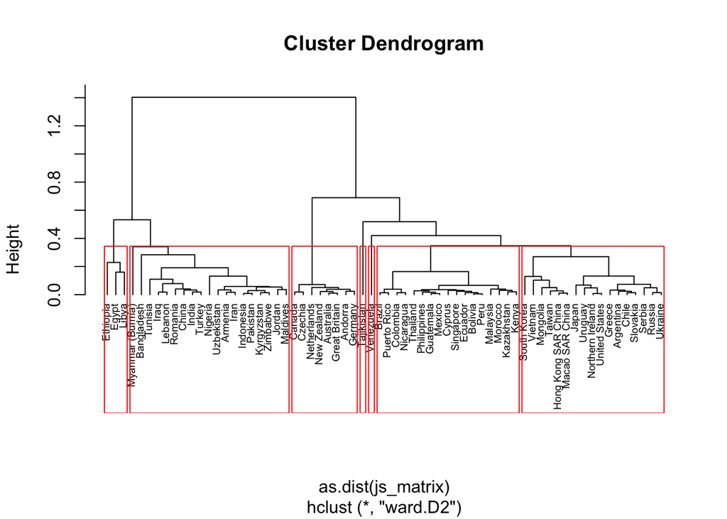

```r
plot(hc, hang = -1, cex = 0.6)

rect.hclust(hc, k, border="red")
```

**K = 10**

Countries Grouped by Cluster

| Cluster | Countries |
| --- | --- |
| 1 | Andorra, Australia, Canada, Czechia, Germany, Great Britain, Netherlands, New Zealand |
| 2 | Argentina, Chile, Greece, Japan, Northern Ireland, Russia, Serbia, Slovakia, Ukraine, United States, Uruguay |
| 3 | Armenia, China, India, Indonesia, Iran, Iraq, Jordan, Kyrgyzstan, Lebanon, Maldives, Nigeria, Pakistan, Romania, Tunisia, Turkey, Uzbekistan, Zimbabwe |
| 4 | Bangladesh |
| 5 | Bolivia, Brazil, Colombia, Cyprus, Ecuador, Guatemala, Kazakhstan, Kenya, Malaysia, Mexico, Morocco, Nicaragua, Peru, Philippines, Puerto Rico, Singapore, Thailand |
| 6 | Egypt, Ethiopia, Libya |
| 7 | Hong Kong SAR China, Macao SAR China, Mongolia, South Korea, Taiwan, Vietnam |
| 8 | Myanmar (Burma) |
| 9 | Tajikistan |
| 10 | Venezuela |

### 2.3.2 Regions

Our clustering suggests significant geographic regional clustering of countries on their responses to the justifiabilty of these actions, but manually grouping the questions is not easily interpretable. To compare these clusters to existing geographic regions, we plot them as 10 colours on a world map (using `ne_countries` for a more detailed map), again linking with `iso_a3` codes.

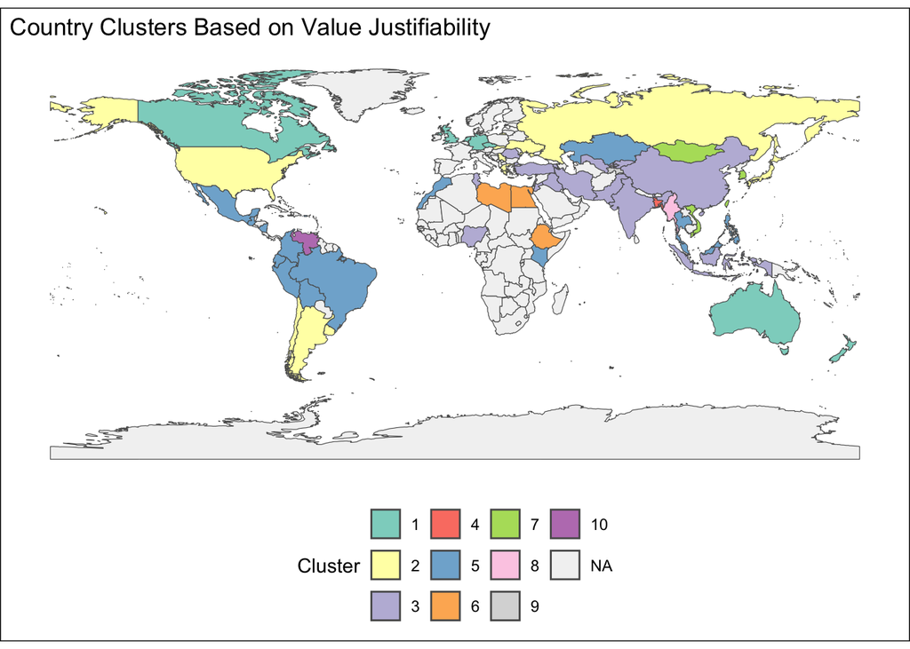

```r
# world map
world <- ne_countries(scale = "medium", returnclass = "sf")

#
world_clusters <- world %>%
  left_join(cluster_df_10, by = c("iso_a3" = "B_COUNTRY_ALPHA"))

# map
ggplot(data = world_clusters) +
  geom_sf(aes(fill = factor(Cluster))) +
  scale_fill_brewer(palette = "Set3", na.value = "grey95", name = "Cluster") +
  theme_minimal() +
  theme(
    panel.grid = element_blank(),
    plot.background = element_rect(fill = "white"),
    legend.position = "bottom"
  ) +
  labs(title = "Country Clusters Based on Value Justifiability")
```

Mapping the country clusters reveals distinct patterns in attitudes towards personal autonomy and moral behaviors (homosexuality, abortion, divorce, premarital sex, suicide, euthanasia, and casual sex) across countries. While geographic proximity appears to be a strong determinant of these moral attitudes, with clear regional patterns emerging, the clusters do not align perfectly with continental groupings. The analysis identifies ten distinct clusters: Western liberal democracies form a cohesive group (Cluster 1), while a mixed cluster of developed and middle-income nations (Cluster 2) bridges traditional Western and non-Western attitudes. A large Islamic-influenced cluster (Cluster 3) spans from North Africa through the Middle East to South Asia, while East Asian nations form their own distinctive group (Cluster 7). Latin American, Southeast Asian, and African nations largely group together (Cluster 5), suggesting similar moral frameworks despite geographic distance, and insinuating there to be a shared underlying explanation. Several single-country clusters (Bangladesh, Myanmar, and Tajikistan) indicate unique moral attitude profiles that don’t align with their neighbors. Three North/East African nations form a distinct group (Cluster 6), while the remaining countries distribute across the clusters in ways that suggest the influence of historical, religious, and developmental factors beyond simple geographic proximity.

These results suggest a significant regional variation in attitudes toward the justifiability of the specified actions, however, further analysis could employ a more complete set of national data to more meaningfully understand global regional differences. There is a particular lack of data across Africa and Europe, which could allow for an interesting lower-level regional analysis on Europe, which generally has the highest variation, or “plurality” (Karumathil and Tripathi 2022), in cultural attitudes.

## 2.4 Prediction

### 2.4.1 Overview and Rationale for Prediction

Having illustrated that the justifiability of the specified actions varies between countries and thus regionally, we investigated the underlying mechanisms of this difference by determining the most important predictors of divorce. In order for sample sizes to be large enough to generate meaningful predictions, we did not compare at the national level.

The rationale for divorce as the outcome variable first considers the fact divorce is only illegal in two countries (the Philippines and Vatican City), which would influence justifiability as explicit social norms (e.g., laws) impact beliefs and values. Further, evaluations of divorce are multifaceted, impacted by cultural individualism, societal wealth, family and religious values (Toth and Kemmelmeier 2009), therefore are predicted by a multitude of individual characteristics. Finally, divorced individuals (who supposedly justify this action) are more supportive to other specified actions, such as abortion (Loll and Hall 2019), suggesting predictors may have some degree of generalisability to other actions of interest.

Classification is defined as a “predictive modelling process” which categorises data into specified classes (Belcic 2024), in this instance a binary factor variable representing unjustifiable (0) justifiable (1) actions, specifically divorce. This decision was based on the choice of similar research to recode these WVS variables scored 1-10 to a 0 and 1 “dichotomy” in which 0 represented scores of 1 - actions deemed never justifiable - and 1, which comprised all other scores in which actions were, to some degree, justifiable (Martínez, Sánchez, and Galindo 2022) (McGee, Benk, and Yüzbaşı 2015).

To ascertain the most significant predictors we instantiated a classification decision tree which was resampled through k-fold cross-validation to obviate issues of overfitting (Prajwala 2015). Decision trees split data into progressively smaller categories through “binary classification judgments” (Belcic 2024) from which a variable importance plot can be created to visualise the main predictors of divorce attitudes. Decision trees are considered “powerful and popular tools for classification and prediction”, their strengths lying in their interpretability, robustness to the presence of outliers (Prajwala 2015), and classification reliability and accuracy (Podgorelec et al. 2002).

### 2.4.2 Investigating Predictors of Divorce - The Process

First a new dataframe was created containing all desired predictors, as well as the chosen outcome variable.

```r
# need to make new dataframe with all desired predictors and outcome as binary factor variable

wvs_dt_df <- wvs_qs %>%
  select(-country_name,
         -B_COUNTRY,
         -B_COUNTRY_ALPHA,
         -N_REGION_ISO,
         -N_REGION_WVS,
         -O1_LONGITUDE,
         -O2_LATITUDE) %>%
  # Create binary outcome variable for Divorce
  mutate(outcome_185 = factor(ifelse(Q185 == 1, 0, 1)))
```

This dataframe was subsequently split into training and test sets (Podgorelec et al. 2002), in which 75% was allocated to the former, and the outcome variable was stratified so each class will be proportionally represented in each set. Cross-validation folds were then specified (k = 10). K-fold cross-validation is a preferable means of determining the likelihood an “outcome is generated by chance” (Gorriz et al. 2024), allows for hyperparameter tuning (Anguita et al. 2012), and outperforms standard hypothesis testing (Gorriz et al. 2024) and leave-one-out cross-validation (Rao, Fung, and Rosales 2008). The number of folds (k = 10) was chosen based on the premise that larger k values risk underfitting and vice versa for smaller k values (Agrawal 2023). Further, researchers have posited standard k values as 5, 10, and 20 (Anguita et al. 2012), from which k = 10 was selected as it arguably mitigates the risk of over- and under-fitting. This is considered a typical k value as it reflects the “trade-off” between bias and variance in error estimation (Gorriz et al. 2024) and support for k = 10 when employing decision trees is cited in the literature (Rao, Fung, and Rosales 2008). Finally, the evaluation metric was defined, in this case we selected the area under the receiver operator characteristic curve, otherwise termed ROC AUC.

The ROC curve illustrates the interplay between the true and false positive rates whereby better classification models have higher true positive rates and curves on the left of the graph, the area below which quantifies the performance of the curve (Vujovic 2021). This area score measures the likelihood a “randomly selected positive has a higher confidence score” than a negative counterpart (Belcic 2024). Higher ROC AUC scores (closer to 1) indicate “excellent” model performance, scores around 0.5 approximate random estimation, and scores closer to 0 indicate “poor” model performance (Prasanna 2024) and denotes that the classification model scores negatives with greater probabilities than positives (Belcic 2024). Both the curve and the area are considered “important” classification metrics (Prasanna 2024), and are beneficial in determining model performance in terms of “ranking predictions” as well as when data is imbalanced (Czakon 2022), which distorts metrics such as accuracy (Prasanna 2024).

```r
# Create training and test sets
set.seed(123)
wvs_split <- initial_split(wvs_dt_df, prop = 0.75, strata = outcome_185)
wvs_train <- training(wvs_split)
wvs_test <- testing(wvs_split)

# Create cross-validation folds
wvs_cv <- vfold_cv(wvs_train, v = 10)

# Set evaluation metrics
eval_metrics <- metric_set(roc_auc)
```

A decision tree model was created, specifying the tunable hyperparameters - cost complexity, tree depth, minimum node size - the model type, classification, and package used to fit the model, rpart. A recipe was written to define the outcome, divorce, and predictors. The included predictors were settlement size and type, urban-rural dimension, important to life values - family, friends, leisure time, politics, work, religion - sex, age, citizenship, whether respondents have children, education level, social class (subjective), and religious denomination. These predictors represent the aforementioned factors that impact attitude formation, as well as other types of regional definition (e.g., urban) which could enhance our understanding of the differences observed. We decided to omit the other actions (Q177-195), as we were trying to determine characteristics that predict regional differences in divorce justifiability and answers to these questions would not yield that result. A workflow combined the model and recipe.

```r
# Create a cross-validated decision tree model
wvs_dt_model <-
  decision_tree(
    cost_complexity = tune(),
    tree_depth = tune(),
    min_n = tune()
  ) %>%
  set_mode("classification") %>%
  set_engine("rpart")

# Create recipe
wvs_dt_recipe <-
  wvs_train %>%
  recipe(outcome_185 ~ .) %>%
  step_rm(Q177, Q178, Q179, Q180, Q181, Q182, Q183, Q184, Q185, Q186, Q187, Q188, Q189, Q190, Q191, Q192, Q193, Q194, Q195)

# Create a workflow for cross-validated model
wvs_dt_workflow <-
  workflow() %>%
  add_recipe(wvs_dt_recipe) %>%
  add_model(wvs_dt_model)
```

```r
# Create a hyperparameter tuning grid
wvs_dt_grid <- expand_grid(
  cost_complexity = c(0.001, 0.01, 0.1),
  tree_depth = c(4, 6, 8),
  min_n = c(5, 10, 20)
)

# Grid search using parallel processing
doParallel::registerDoParallel()

n_cores <- parallel::detectCores() - 1

cl <- makeCluster(n_cores)
registerDoParallel(cl)

wvs_dt_fit <-
  tune_grid(
    wvs_dt_workflow,
    resamples = wvs_cv,
    metrics = eval_metrics,
    grid = wvs_dt_grid
  )

stopCluster(cl)
```

**Hyperparameters**

We then plotted a tuning grid which revealed that according to the best ROC AUC value, the model where cost complexity is 0.001, tree depth is 8, and minimum node size is 5, was the optimal classification model.

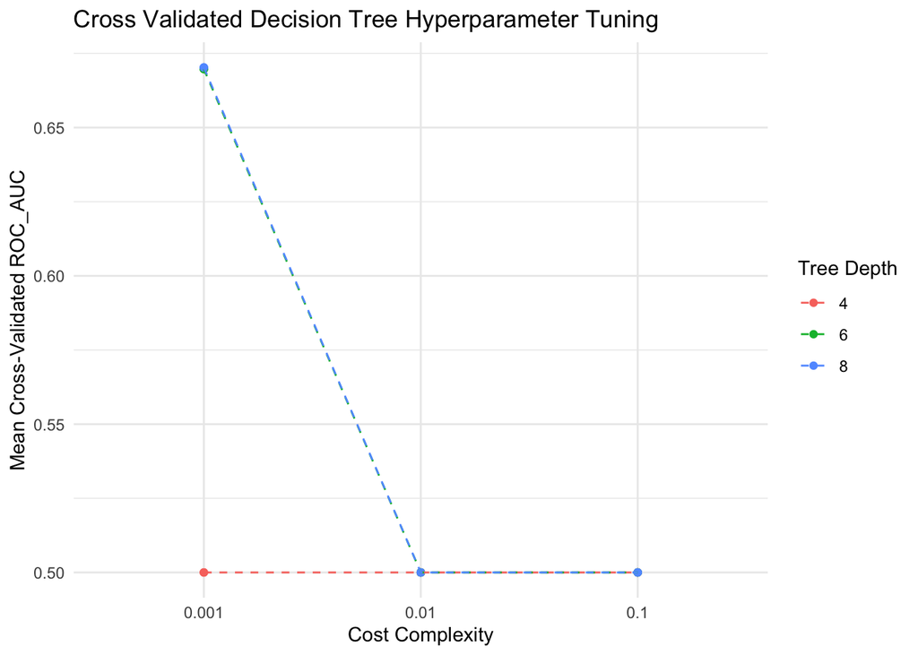

```r
# Plot hyperparameters
wvs_dt_fit %>%
  collect_metrics() %>%
  filter(.metric == "roc_auc") %>%
  ggplot(aes(x = as.factor(cost_complexity), y = mean, group = tree_depth, color = as.factor(tree_depth))) +  geom_point() +
  geom_line(linetype = "dashed") +
  theme_minimal() +
  labs(x = "Cost Complexity", y = "Mean Cross-Validated ROC_AUC", color = "Tree Depth") +
  ggtitle("Cross Validated Decision Tree Hyperparameter Tuning")
```

```r
# Select best model based on R^2
highest_roc_dt <- select_best(wvs_dt_fit, metric = "roc_auc")
highest_roc_dt %>% kable()
```

| cost_complexity | tree_depth | min_n | .config |
| --- | --- | --- | --- |
| 0.001 | 8 | 5 | Preprocessor1_Model07 |

This model was fitted to the training set and evaluated on the test set. Unseen test data is used for model evaluation to protect against overfitting and inaccurate predictions (Belcic 2024).

```r
# Fit best model to training set
wvs_final_fit <-
  wvs_dt_workflow %>%
  finalize_workflow(highest_roc_dt) %>%
  fit(wvs_train)
```

### 2.4.3 Investigating Predictors of Divorce - The Outcome

The ROC AUC score of over 0.5 indicates that the classification predictions made exceed random estimation (0.5), yet are not perfect indicating a margin of error in model predictions.

```r
# Evaluate best model on test set
wvs_final_fit %>%
  augment(new_data = wvs_test) %>%
  eval_metrics(truth = outcome_185, estimate = '.pred_0', '.pred_1', event_level = "second") %>% kable()
```

| .metric | .estimator | .estimate |
| --- | --- | --- |
| roc_auc | binary | 0.6701818 |

The decision tree was then visualised however, due to the default formatting of the rpart.plot function it was not easily interpretable. Considering this, and that the objective of this analysis was to determine the most important predictors of divorce justifiability, we created a variable importance plot with the vip function.

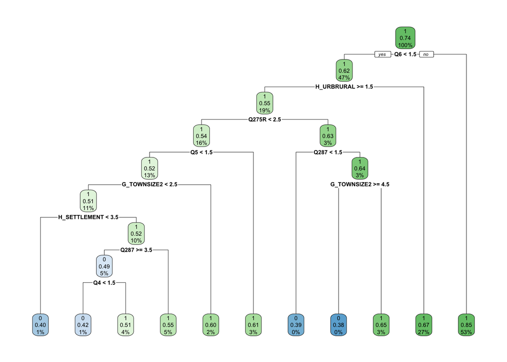

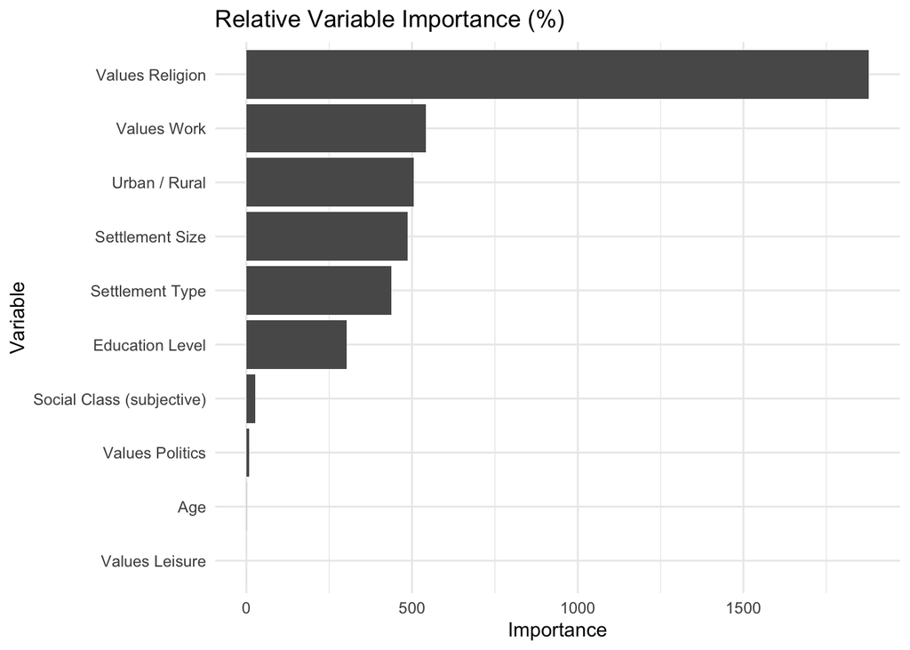

This visualisation yielded that, as we expected, religiosity was by far the most important predictor of divorce justifiability. The following five predictors were similar in terms of importance: valuing work, urban-rural, settlement size, settlement type, and education level. Surprisingly social class and valuing of politics were marginally important predictors, converse to research findings of an association between political conservatism and economic and moral issues (Stack, Adamczyk, and Cao 2010) and national wealth predicting “evaluations of divorce” (Toth and Kemmelmeier 2009).

Findings would likely differ if the model was applied to different outcomes, such as euthanasia justifiability, which is notably affected by age, socioeconomic status, urban-rural differences (Tutić Grokša et al. 2025), as well as religious denominations (Karumathil & Tripathi, 2022). Despite this, we could arguably expect religiosity to remain an important predictor for many of the action justifiability values as it has been related to euthanasia (Inglehart et al. 2021), homosexuality (Furnham and Saito 2009), abortion (Tutić Grokša et al. 2025), and suicide (Lester 2003). The sexual behaviours - premarital and casual sex - are seemingly more influenced by sexual regulation (Broude 1975).

## Statement on Use of Generative AI Tools, As Per School and Course-Specific Policies

In response to the guidance on the full authorised use of generative AI in assessment, we have utilised generative AI tools throughout the learning and assessment process as permitted. These tools were used in the following ways while making sure we used these tools responsibly to ensure our learning and development align with course expectations. Under Descriptive Statistics, we used AI to help us develop clean and insightful graphs, linking to the `question_labels` created to better display out outputs, and to investigate the alternate measure of the geometric mean Under Clustering Actions, we used AI to implement the process of investigating Jensen-Shannon divergence, and later in Part 2, used AI to aid us with parallel processing due to the large amount of data involved Furthermore, in this section we used AI to print the outputs of agglomerative hierarchical clustering for our desired `k` value Additionally, we used AI to determine the point of maximum curvature, and alternative points of curvature (seen in the graph which was generated by AI) to help us define an appropriate `eps` value. Under Part 2.1 Country Means, we used AI to convert our graphs displaying the geometric mean per question, per country and national-global mean divergence into an interactive plot Furthermore, geographic maps were largely aided by AI Under Part 2.4 Prediction, we used AI to create the binary classification of justification (where “Never Justifiable” became 0, and anything greater than that became 1) and to fix issues with evaluating the model on the test set using ROC AUC Within our models, we used AI to suggest suitable parameters and aid with hyperparameter tuning (e.g. `tree_depth`, `minPts`, `eps`, `cost_complexity`) To avoid any undue repercussions, we have stated throughout the sections of this assignment where we were aided by ChatGPT, to the best of our ability to ensure transparency and adherence to the guidelines while mitigating any concerns.

## References

Agrawal, Saurav. 2023. “Hyperparameter Tuning of KNN Classifier. Medium.” June 4, 2023. https://medium.com/@agrawalsam1997/hyperparameter-tuning-of-knn-classifier-a32f31af25c7.

Almosaed, Nora. 2004. “Violence Against Women: A Cross‐cultural Perspective.” *Journal of Muslim Minority Affairs* 24 (1): 67–88. https://doi.org/10.1080/1360200042000212124.

Anguita, Davide, Luca Ghelardoni, Alessandro Ghio, Luca Oneto, and Sandro Ridella. 2012. “The ‘k’ in k-Fold Cross Validation.” *Computational Intelligence*.

Babb, Alexius Q. 2015. “Stealing Is Stealing: A Cross-Cultural Analysis on the Perception of Criminality for Physical Theft Versus Illegal Downloading.” *IU Journal of Undergraduate Research* 1 (1): 54–59. https://doi.org/10.14434/iujur.v1i1.13320.

Belcic, Ivan. 2024. “What Is Classification in Machine Learning? IBM.” October 15, 2024. https://www.ibm.com/think/topics/classification-machine-learning.

Broude, Gwen J. 1975. “Norms of Premarital Sexual Behavior: A Cross-Cultural Study.” *Ethos* 3 (3): 381–402. https://www.jstor.org/stable/640100.

Chon, Don Soo. 2015. “Gender Equality, Liberalism and Attitude Toward Prostitution: Variation in Cross-National Study.” *Journal of Family Violence* 30 (7): 827–38. https://doi.org/10.1007/s10896-015-9713-y.

Colucci, Erminia, and David Lester. 2012. *Suicide and Culture: Understanding the Context*. Hogrefe Publishing GmbH.

Czakon, Jakub. 2022. “F1 Score Vs ROC AUC Vs Accuracy Vs PR AUC: Which Evaluation Metric Should You Choose? Neptune.ai.” July 21, 2022. https://neptune.ai/blog/f1-score-accuracy-roc-auc-pr-auc.

Ember, Carol R., and Melvin Ember. 2005. “Explaining Corporal Punishment of Children: A Cross-Cultural Study.” *American Anthropologist* 107 (4): 609–19. https://doi.org/10.1525/aa.2005.107.4.609.

Furnham, Adrian, and Kaoru Saito. 2009. “A Cross-Cultural Study of Attitudes Toward and Beliefs about, Male Homosexuality.” *Journal of Homosexuality* 56 (3): 299–318. https://doi.org/10.1080/00918360902728525.

Gorriz, Juan M., R. Martin Clemente, F. Segovia, J. Ramirez, A. Ortiz, and J. Suckling. 2024. “Is k-Fold Cross Validation the Best Model Selection Method for Machine Learning?” arXiv. https://doi.org/10.48550/arXiv.2401.16407.

Green, Eva G. T., Jean-Claude Deschamps, and Dario Páez. 2005. “Variation of Individualism and Collectivism Within and Between 20 Countries: A Typological Analysis.” *Journal of Cross-Cultural Psychology* 36 (3): 321–39. https://doi.org/10.1177/0022022104273654.

Haerpfer, C., R. Inglehart, A. Moreno, C. Welzel, K. Kizilova, J. Diez-Medrano, M. Lagos, P. Norris, E. Ponarin, and B. Puranen, eds. 2022. “World Values Survey: Round Seven – Country-Pooled Datafile Version 6.0.” https://doi.org/https://doi.org/10.14281/18241.24.

Inglehart, Ronald C., Ryan Nash, Quais N. Hassan, and Judith Schwartzbaum. 2021. “Attitudes Toward Euthanasia: A Longitudinal Analysis of the Role of Economic, Cultural, and Health-Related Factors.” *Journal of Pain and Symptom Management* 62 (3): 559–69. https://doi.org/10.1016/j.jpainsymman.2021.01.009.

Karumathil, Anjana A., and Ritu Tripathi. 2022. “Culture and Attitudes Towards Euthanasia: An Integrative Review.” *OMEGA - Journal of Death and Dying* 86 (2): 688–720. https://doi.org/10.1177/0030222820984655.

Lee, Yueh-Ting, Russ Kleinbach, Pei-Cheng Hu, Zu-Zhi Peng, and Xiang-Yang Chen. 1996. “Cross-Cultural Research on Euthanasia and Abortion.” *Journal of Social Issues* 52 (2): 131–48. https://doi.org/10.1111/j.1540-4560.1996.tb01572.x.

Lee, Yueh-Ting, Seiji Takaku, Victor Ottati, and Gonggu Yan. 2004. “Perception and Interpretation of Terrorism, Justice, and Conflict: Three Cultures and Two Sides of One Coin.”

Lester, David. 2003. “Cross-Cultural Perspectives on Suicide.” In *Handbook of Death and Dying*. SAGE.

Loll, Dana, and Kelli Stidham Hall. 2019. “Differences in Abortion Attitudes by Policy Context and Between Men and Women in the World Values Survey.” *Women & Health* 59 (5): 465–80. https://doi.org/10.1080/03630242.2018.1508539.

Martínez, Pilar Rodríguez, Antonio Jesús Segura Sánchez, and Carmelo Jesús Aguilera Galindo. 2022. “Justification of Terrorism According to World Values Survey (2017–2020).” *Research in Globalization* 5 (December): 100085. https://doi.org/10.1016/j.resglo.2022.100085.

McCarthy, Daniel, and Ian Brunton-Smith. 2024. “Attitudes Towards the Death Penalty: An Assessment of Individual and Country-Level Differences.” *European Journal of Criminology* 21 (1): 116–39. https://doi.org/10.1177/14773708221097670.

McGee, Robert W., Serkan Benk, and Bahadır Yüzbaşı. 2015. “Religion and Ethical Attitudes Toward Accepting a Bribe: A Comparative Study.” *Religions* 6 (4): 1168–81. https://doi.org/10.3390/rel6041168.

Navot, Doron, Yaniv Reingewertz, and Nissim Cohen. 2016. “Speed or Greed? High Wages and Corruption Among Public Servants.” *Administration & Society* 48 (5): 580–601. https://doi.org/10.1177/0095399715623313.

Podgorelec, Vili, Peter Kokol, Bruno Stiglic, and Ivan Rozman. 2002. “Decision Trees: An Overview and Their Use in Medicine.” *Journal of Medical Systems* 26 (5): 445–63. https://doi.org/10.1023/A:1016409317640.

Prajwala, T. R. 2015. “A Comparative Study on Decision Tree and Random Forest Using r Tool.” *IJARCCE*, January, 196–99. https://doi.org/10.17148/IJARCCE.2015.4142.

Prasanna, Chanaka. 2024. “Understanding ROC and AUC in Model Evaluation. Medium.” July 19, 2024. https://medium.com/@chanakapinfo/understanding-roc-and-auc-in-model-evaluation-88fe4ac7dfc7.

Rao, R. Bharat, Glenn Fung, and Romer Rosales. 2008. “On the Dangers of Cross-Validation. An Experimental Evaluation.” In *Proceedings of the 2008 SIAM International Conference on Data Mining (SDM)*, 588–96. Proceedings. Society for Industrial; Applied Mathematics. https://doi.org/10.1137/1.9781611972788.54.

Roberts, Louisa L. 2019. “Changing Worldwide Attitudes Toward Homosexuality: The Influence of Global and Region-Specific Cultures, 1981–2012.” *Social Science Research* 80 (May): 114–31. https://doi.org/10.1016/j.ssresearch.2018.12.003.

Stack, Steven, Amy Adamczyk, and Liqun Cao. 2010. “Survivalism and Public Opinion on Criminality: A Cross-National Analysis of Prostitution.” *Social Forces* 88 (4): 1703–26. https://doi.org/10.1353/sof.2010.0029.

Tausch, Arno. 2019. “Multivariate Analyses of the Global Acceptability Rates of Male Intimate Partner Violence (IPV) Against Women Based on World Values Survey Data.” *The International Journal of Health Planning and Management* 34 (4): 1155–94. https://doi.org/10.1002/hpm.2781.

Torgler, Benno, and Friedrich Schneider. 2005. “Attitudes Towards Paying Taxes in Austria: An Empirical Analysis.” *Empirica* 32 (2): 231–50. https://doi.org/10.1007/s10663-004-8328-y.

Torgler, Benno, and Neven T. Valev. 2010. “Gender and Public Attitudes Toward Corruption and Tax Evasion.” *Contemporary Economic Policy* 28 (4): 554–68. https://doi.org/10.1111/j.1465-7287.2009.00188.x.

Toth, Katalin, and Markus Kemmelmeier. 2009. “Divorce Attitudes Around the World: Distinguishing the Impact of Culture on Evaluations and Attitude Structure.” *Cross-Cultural Research* 43 (3): 280–97. https://doi.org/10.1177/1069397109336648.

Tutić Grokša, Ivana, Ana Depope, Tijana Trako Poljak, Igor Eterović, Toni Buterin, Robert Doričić, Mariana Gensabella, et al. 2025. “Students’ Attitudes Toward Euthanasia and Abortion: A Cross-Cultural Study in Three Mediterranean Countries.” *BMC Medical Ethics* 26 (1): 9. https://doi.org/10.1186/s12910-025-01167-8.

Vujovic, Željko Ð. 2021. “Classification Model Evaluation Metrics.” *International Journal of Advanced Computer Science and Applications (IJACSA)* 12 (6). https://doi.org/10.14569/IJACSA.2021.0120670.

World Values Survey. n.d. “WVS Database. World Values Survey.” Accessed February 16, 2025. https://www.worldvaluessurvey.org/WVSContents.jsp.

Wormald, Benjamin. 2014. “Religion in Latin America. Pew Research Center.” November 13, 2014. https://www.pewresearch.org/religion/2014/11/13/religion-in-latin-america/.

Zhang, Zhiyuan, Guoxin Ni, and Yanguo Xu. 2020. “Comparison of Trajectory Clustering Methods Based on k-Means and DBSCAN.” In *2020 IEEE International Conference on Information Technology,big Data and Artificial Intelligence (ICIBA)*, 1:557–61. https://doi.org/10.1109/ICIBA50161.2020.9277214.